# Máster en Ciencia de Datos: Visualización Avanzada de Datos

Tarea Visualizacion de datos Espaciales

Mayra Russo Botero

28 February 2019

*Librerías*

```r
packages = c('readxl','raster','dplyr','tidyr','tmap','ggplot2','stringr','stringi','maptools',
            'mapview','animation')
#use this function to check if each package is on the local machine
#if a package is installed, it will be loaded
#if any are not, the missing package(s) will be installed and loaded
package.check <- lapply(packages, FUN = function(x) {
  if (!require(x, character.only = TRUE)) {
    install.packages(x, dependencies = TRUE)
    library(x, character.only = TRUE)
  }
})
```

```
## Checking rgeos availability: TRUE
```

1. a)Cargamos el fichero con los datos poblacionales Com. Valenciana años 1998-2018. Los datos que se van a combinar con el mapa han sido descargados del Instituto Nacional de Estadística. En el enlace https://www.ine.es/dynt3/inebase/index.htm?padre=525 ##Los tres ficheros (1 por provincia) descargados del INE los junte previo en un excel master file; tambíen he decidido importar desde 1998, porque no hay datos del padrón para 1997, y 1996 a partir de Mayo

```r
Pob_Com_Valenciana <- read_excel("./data/Pob Com Valenciana.xls")
```

b)Arreglamos los datos para poder emparejarlos con los datos de los mapas

```r
Pob_Com_Valenciana2 <-Pob_Com_Valenciana %>% mutate(Municipio = str_replace_all(Municipio,'[[:digit:]0-9]','')) %>% mutate(Municipio=str_trim(Municipio,side='left')) #%>% mutate(Municipio=stri_trans_general(Municipio,"Latin-ASCII")) #quitamos acentos
dat1 <- data.frame(stringsAsFactors=FALSE,do.call(rbind, strsplit(as.vector(Pob_Com_Valenciana2$Municipio), split = "/")))
names(dat1) <- c("Municipio","Muni1") #separamos nombre de municipios que tienen variaciones en valenciano/castellano
```

Más limpieza

```r
#todo lo que sigue es para mover los articulos al final de los string, frente
#TODO intentar arreglar esto
dat2<-data.frame(stringsAsFactors=FALSE,sub(pattern ='^(.*), la', replacement = "La \\1", x = dat1$Municipio,ignore.case = TRUE))
colnames(dat2)[1] <- "Municipio"
dat3<-data.frame(stringsAsFactors=FALSE,sub(pattern ='^(.*), el', replacement = "El \\1", x = dat2$Municipio,ignore.case = TRUE))
colnames(dat3)[1] <- "Municipio"
dat4<-data.frame(stringsAsFactors=FALSE,sub(pattern ="^(.*), l'", replacement = "L'\\1", x = dat3$Municipio,ignore.case = TRUE))
colnames(dat4)[1] <- "Municipio"
dat5<-data.frame(stringsAsFactors=FALSE,sub(pattern ="^(.*), les", replacement = "Les \\1", x = dat4$Municipio,ignore.case = TRUE))
colnames(dat5)[1] <- "Municipio"
dat6<-data.frame(stringsAsFactors=FALSE,sub(pattern ="^(.*), los", replacement = "Los \\1", x = dat5$Municipio,ignore.case = TRUE))
names(dat6) <- c("Municipio")
```

c)Guardo dataframe final, para unir con el DF de poligonos espaciales

```r
Pob_Com_Valenciana2 <- cbind.data.frame(dat6$Municipio,Pob_Com_Valenciana2,stringsAsFactors=FALSE)
Pob_Com_Valenciana2<-select(Pob_Com_Valenciana2,-"Municipio")
colnames(Pob_Com_Valenciana2)[1] <- "Municipio"
# Pob_Com_Valenciana2 <-Pob_Com_Valenciana2%>%mutate(Municipio=as.character(levels(Pob_Com_Valenciana2$Municipio)))
# Pob_Com_Valenciana2[-1]<-lapply(Pob_Com_Valenciana2[-1],as.numeric) #pob info as.numeric
save(Pob_Com_Valenciana2,file="./data/PobCVlc.RData")
#load(file="./data/PobCVlc.RData")
#str(Pob_Com_Valenciana2)
```

2. Descarga del mapa de la Comunidad Valenciana

```r
SpainComVl<- getData('GADM',country='ESP',level=4)
ComVal<-SpainComVl[SpainComVl@data$NAME_1 == "Comunidad Valenciana",]
head(ComVal@data,3)
```

```
##        GID_0 NAME_0    GID_1               NAME_1      GID_2   NAME_2
## 120774   ESP  Spain ESP.10_1 Comunidad Valenciana ESP.10.1_1 Alicante
## 120735   ESP  Spain ESP.10_1 Comunidad Valenciana ESP.10.1_1 Alicante
## 120801   ESP  Spain ESP.10_1 Comunidad Valenciana ESP.10.1_1 Alicante
##               GID_3   NAME_3          GID_4   NAME_4      VARNAME_4
## 120774 ESP.10.1.1_1 Alacanti ESP.10.1.1.1_1    Agost           <NA>
## 120735 ESP.10.1.1_1 Alacanti ESP.10.1.1.2_1   Aigües Aguas de Busot
## 120801 ESP.10.1.1_1 Alacanti ESP.10.1.1.3_1 Alicante        Alacant
##              TYPE_4    ENGTYPE_4 CC_4
## 120774 Municipality Municipality <NA>
## 120735 Municipality Municipality <NA>
## 120801 Municipality Municipality <NA>
```

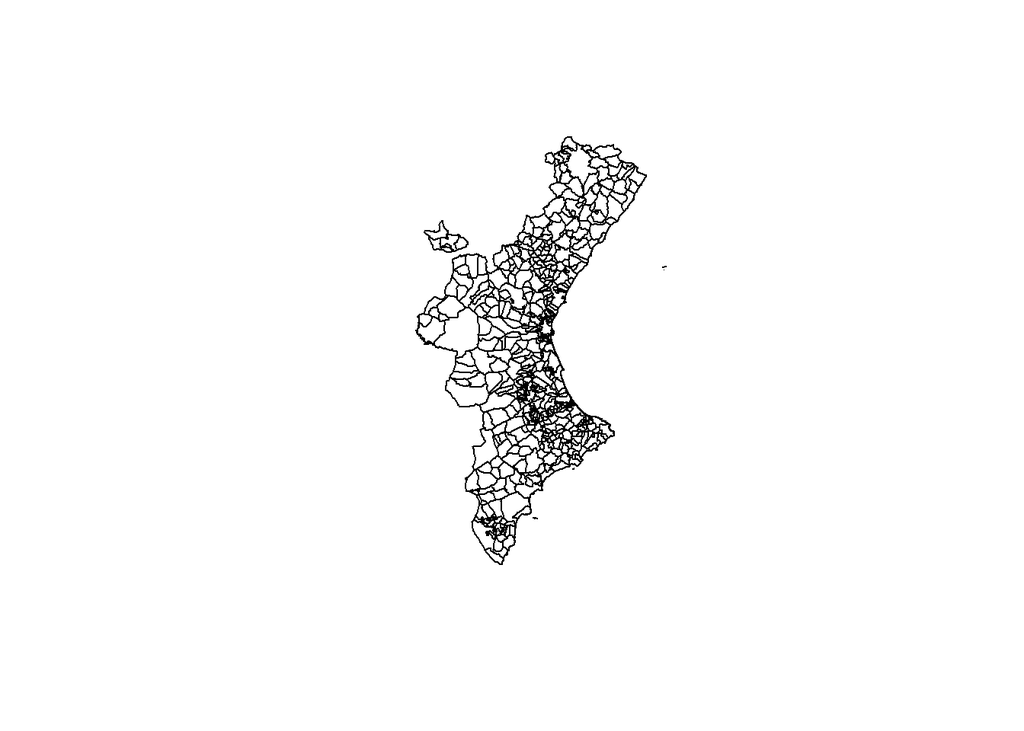

```r
ComVal<-ComVal[,-(11:14)]
plot(ComVal)
```

```r
# #Identificadores
# ComVal@polygons[[1]]@ID
# str(ComVal@polygons[[1]],max.level = 4)
# ComVal@polygons[[1]]@Polygons[[1]]
# str(ComVal@polygons[[1]]@Polygons[[1]],max.level = 4)
```

3. Duplicados/Diferencias

```r
any(duplicated(ComVal$NAME_4))
```

```
## [1] TRUE
```

```r
ComVal$NAME_4[duplicated(ComVal$NAME_4)]
```

```
## [1] "Alicante" "Valencia" "Xàtiva"   "Domeño"
```

```r
#"Alicante" "Valencia" "Xàtiva"   "Domeño"
#borro duplicados
ComVal<- ComVal[!duplicated(ComVal@data$NAME_4),]

# any(duplicated(Pob_Com_Valenciana2$Municipio))
# #Pob_Com_Valenciana$Municipio[duplicated(Pob_Com_Valenciana2$Municipio)]
# # #
# ### Buscamos coincidencias en ambos sentidos (se podria hacer con la librería operaciones join dplyr )
# ###
# all((ComVal$NAME_4 %in% Pob_Com_Valenciana2$Municipio))
# ##
# ### Coincidencida en el otro sentido
# all((Pob_Com_Valenciana2$Municipio %in% ComVal$NAME_4))
# setdiff(ComVal$NAME_4,Pob_Com_Valenciana2$Municipio) #esto es lo que hay en maps
# setdiff(Pob_Com_Valenciana2$Municipio,ComVal$NAME_4) #estas en el mio
```

# Arreglo diferencias

```r
Pob_Com_Valenciana2$Municipio[Pob_Com_Valenciana2$Municipio == "L'Atzúbia"] <- "Adsubia"
Pob_Com_Valenciana2$Municipio[Pob_Com_Valenciana2$Municipio == "Calp"] <- "Calpe"
Pob_Com_Valenciana2$Municipio[Pob_Com_Valenciana2$Municipio == "Benigembla"] <- "Binigembla"
Pob_Com_Valenciana2$Municipio[Pob_Com_Valenciana2$Municipio == "El Pobletss"] <- "Els Poblets"
Pob_Com_Valenciana2$Municipio[Pob_Com_Valenciana2$Municipio == "València"] <- "Valencia"
Pob_Com_Valenciana2$Municipio[Pob_Com_Valenciana2$Municipio == "Alboraia"] <- "Alboraya"
Pob_Com_Valenciana2$Municipio[Pob_Com_Valenciana2$Municipio == "Vila-real"] <- "Villarreal"
Pob_Com_Valenciana2$Municipio[Pob_Com_Valenciana2$Municipio == "Alfara de la Baronia"] <- "Alfara de Algimia"
Pob_Com_Valenciana2$Municipio[Pob_Com_Valenciana2$Municipio == "Almassora"] <- "Almazora"
Pob_Com_Valenciana2$Municipio[Pob_Com_Valenciana2$Municipio == "Ares del Maestrat"] <- "Ares del Maestre"
Pob_Com_Valenciana2$Municipio[Pob_Com_Valenciana2$Municipio == "Benassal"] <- "Benasal"
Pob_Com_Valenciana2$Municipio[Pob_Com_Valenciana2$Municipio == "Benigànim"] <- "Benigánim"
Pob_Com_Valenciana2$Municipio[Pob_Com_Valenciana2$Municipio == "Benissanó"] <- "Benisanó"
Pob_Com_Valenciana2$Municipio[Pob_Com_Valenciana2$Municipio == "Benissuera"] <- "Benisuera"
Pob_Com_Valenciana2$Municipio[Pob_Com_Valenciana2$Municipio == "Borriana"] <- "Burriana"
Pob_Com_Valenciana2$Municipio[Pob_Com_Valenciana2$Municipio == "Callosa d'en Sarrià"] <- "Callosa d'En Sarrià"
Pob_Com_Valenciana2$Municipio[Pob_Com_Valenciana2$Municipio == "El Fondó de les Neus"] <- "Hondón de las Nieves"
Pob_Com_Valenciana2$Municipio[Pob_Com_Valenciana2$Municipio == "El Pinós"] <- "Pinoso"
Pob_Com_Valenciana2$Municipio[Pob_Com_Valenciana2$Municipio == "El Puig de Santa Maria"] <- "Puig"
Pob_Com_Valenciana2$Municipio[Pob_Com_Valenciana2$Municipio == "El Real de Gandía"] <- "Real de Gandía"
Pob_Com_Valenciana2$Municipio[Pob_Com_Valenciana2$Municipio == "Guadasséquies"] <- "Guadasequies"
Pob_Com_Valenciana2$Municipio[Pob_Com_Valenciana2$Municipio == "L'Alqueria de la Comtessa"] <- "Alquería de la Condesa"
Pob_Com_Valenciana2$Municipio[Pob_Com_Valenciana2$Municipio == "La Serratella"] <- "Sarratella"
Pob_Com_Valenciana2$Municipio[Pob_Com_Valenciana2$Municipio == "La Torre d'en Doménec"] <- "Torre Endoménech"
Pob_Com_Valenciana2$Municipio[Pob_Com_Valenciana2$Municipio == "La Vall d'Ebo"] <- "Vall de Ebo"
Pob_Com_Valenciana2$Municipio[Pob_Com_Valenciana2$Municipio == "Les Alqueries"] <- "Alquerías del Niño Perdido"
Pob_Com_Valenciana2$Municipio[Pob_Com_Valenciana2$Municipio == "Llocnou de la Corona"] <- "Lugar Nuevo de la Corona"
Pob_Com_Valenciana2$Municipio[Pob_Com_Valenciana2$Municipio == "Llucena"] <- "Lucena del Cid"
Pob_Com_Valenciana2$Municipio[Pob_Com_Valenciana2$Municipio == "Massalavés"] <- "Masalavés"
Pob_Com_Valenciana2$Municipio[Pob_Com_Valenciana2$Municipio == "Montitxelvo"] <- "Montichelvo"
Pob_Com_Valenciana2$Municipio[Pob_Com_Valenciana2$Municipio == "Montroi"] <- "Montroy"
Pob_Com_Valenciana2$Municipio[Pob_Com_Valenciana2$Municipio == "Montserrat"] <- "Monserrat"
Pob_Com_Valenciana2$Municipio[Pob_Com_Valenciana2$Municipio == "Peníscola"] <- "Peñíscola"
Pob_Com_Valenciana2$Municipio[Pob_Com_Valenciana2$Municipio == "Potries"] <- "Potríes"
Pob_Com_Valenciana2$Municipio[Pob_Com_Valenciana2$Municipio == "Rafelbunyol"] <- "Rafelbuñol"
Pob_Com_Valenciana2$Municipio[Pob_Com_Valenciana2$Municipio == "Real"] <- "Real de Montroi"
Pob_Com_Valenciana2$Municipio[Pob_Com_Valenciana2$Municipio == "Sant Joanet"] <- "San Juan de Énova"
Pob_Com_Valenciana2$Municipio[Pob_Com_Valenciana2$Municipio == "Tàrbena"] <- "Tárbena"
Pob_Com_Valenciana2$Municipio[Pob_Com_Valenciana2$Municipio == "Useras"] <- "Les Useras"
Pob_Com_Valenciana2$Municipio[Pob_Com_Valenciana2$Municipio == "Vilallonga"] <- "Villalonga"
Pob_Com_Valenciana2$Municipio[Pob_Com_Valenciana2$Municipio == "Vistabella del Maestrat"] <- "Vistabella del Maestrazgo"
Pob_Com_Valenciana2$Municipio[Pob_Com_Valenciana2$Municipio == "Xaló"] <- "Jalón"
Pob_Com_Valenciana2$Municipio[Pob_Com_Valenciana2$Municipio == "Xert"] <- "Chert"
```

Unión de los dataframes

```r
ComVal1<-sp::merge(ComVal,Pob_Com_Valenciana2,by.x="NAME_4",by.y="Municipio",all.x=TRUE,incomparables = NULL)
ComVal2<-sp::merge(ComVal,Pob_Com_Valenciana2,by.x="NAME_4",by.y="Municipio",all.x=TRUE,incomparables = NULL)
ComVal2@data <- ComVal2@data %>% gather(year, population,'2018':'1998')
```

Preparación del mapa ##leyenda con breaks para dibujar la población y con ello asignar un color

```r
# Colores para la población

colores <- viridis::inferno(10)

breaks <- c(0, 500, 2500, 5000, 10000, 20000, 70000, 150000, 250000,Inf)

leyend <- c("De 0 a 500 habitantes",
               "De 500 a 2,500 habitantes",
               "De 2,500 a 5,000 habitantes",
               "De 5,000 a 10,000 habitantes",
               "De 10,000 a 20,000 habitantes",
               "De 20,000 a 70,000 habitantes",
               "De 70,000 a 150,000 habitantes",
               "De 150,000 a 250,000 habitantes",
               "250,000 o más habitantes")
```

```r
tmap_mode("plot")
```

```
## tmap mode set to plotting
```

```r
tm_shape(ComVal1)+
    tm_fill(col = "1998",
            colorNA=NULL,
            style = "fixed",
            palette = colores,
            breaks = breaks ,
            labels = leyend,
            title = paste("Población",1998))+tm_borders()+
    tm_layout(main.title = paste("Comunidad Valenciana"),
              title.size = 2,
              legend.outside = T,
              legend.outside.position = c("right"))
```

```
## Some legend labels were too wide. These labels have been resized to 0.64. Increase legend.width (argument of tm_layout) to make the legend wider and therefore the labels larger.
```

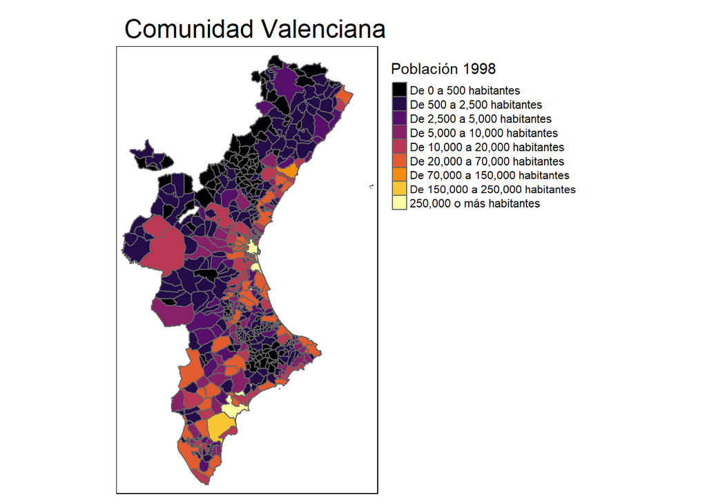

Ahora dibujo el mapa de 1998 en modo view

```r
tmap_mode("view")
```

```
## tmap mode set to interactive viewing
```

```r
tm_shape(ComVal1)+
    tm_fill(col = "1998",
            colorNA=NULL,
            style = "fixed",
            palette = colores,
            breaks = breaks ,
            labels = leyend,
            title = paste("Población",1998))+tm_borders()+
    tm_layout(main.title = paste("Comunidad Valenciana"),
              title.size = 2,
              legend.outside = T,
              legend.outside.position = c("right"))
```

[interactive chart not shown]

La población municipal para los años 1998-2018 (modo plot)

```r
tmap_mode("plot")
```

```
## tmap mode set to plotting
```

```
## Some legend labels were too wide. These labels have been resized to 0.64. Increase legend.width (argument of tm_layout) to make the legend wider and therefore the labels larger.
```

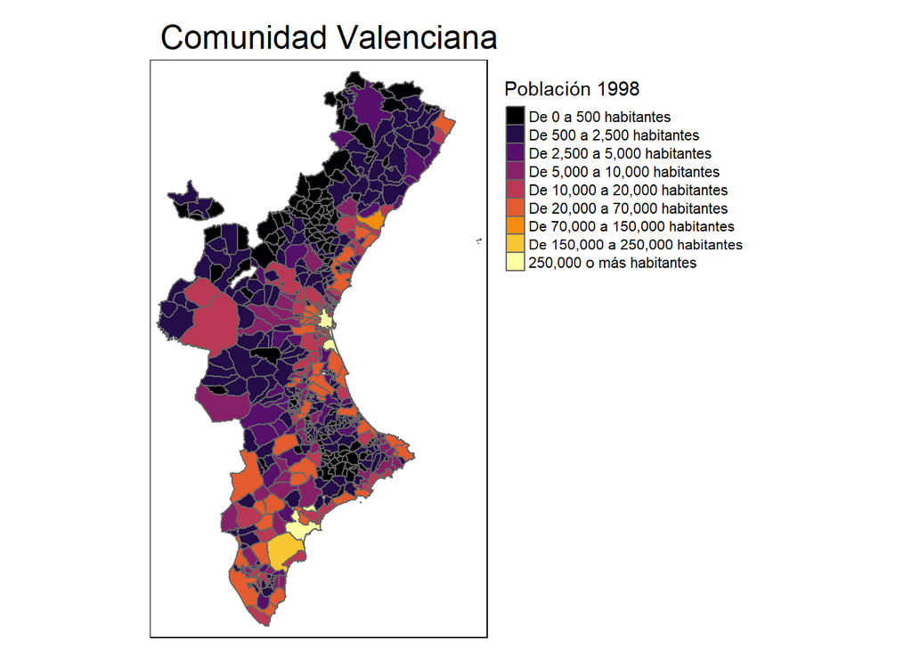

```
## Some legend labels were too wide. These labels have been resized to 0.64. Increase legend.width (argument of tm_layout) to make the legend wider and therefore the labels larger.
```

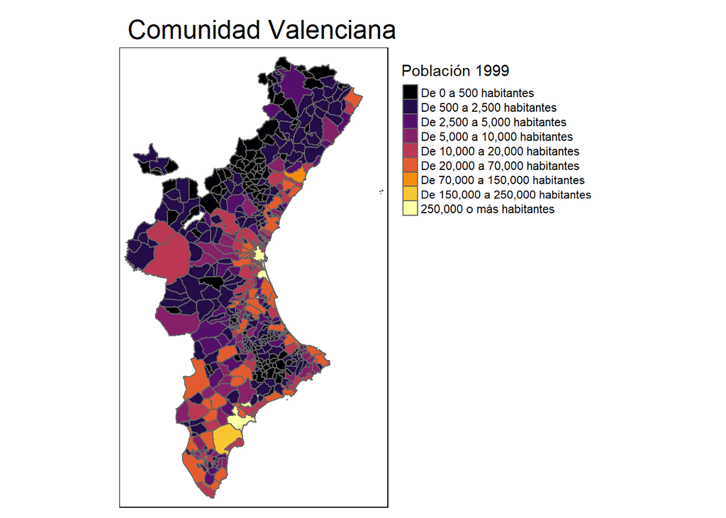

```
## Some legend labels were too wide. These labels have been resized to 0.64. Increase legend.width (argument of tm_layout) to make the legend wider and therefore the labels larger.
```

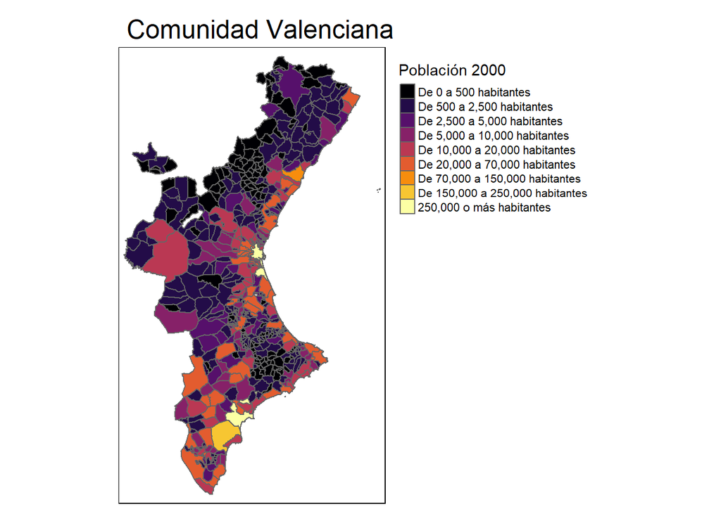

```
## Some legend labels were too wide. These labels have been resized to 0.64. Increase legend.width (argument of tm_layout) to make the legend wider and therefore the labels larger.
```

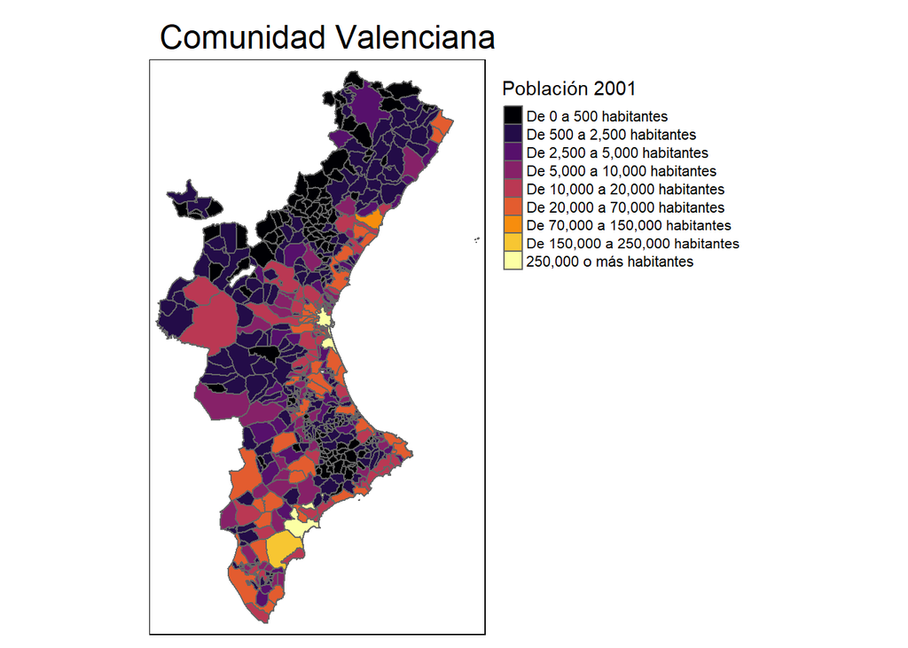

```
## Some legend labels were too wide. These labels have been resized to 0.64. Increase legend.width (argument of tm_layout) to make the legend wider and therefore the labels larger.
```

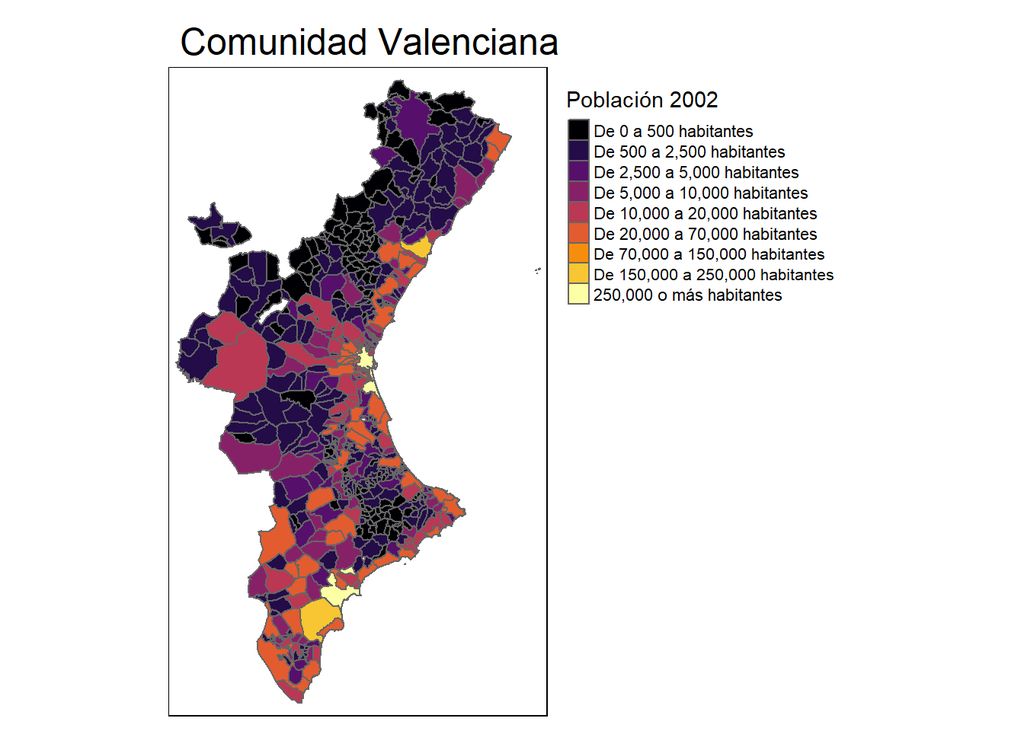

```
## Some legend labels were too wide. These labels have been resized to 0.64. Increase legend.width (argument of tm_layout) to make the legend wider and therefore the labels larger.
```

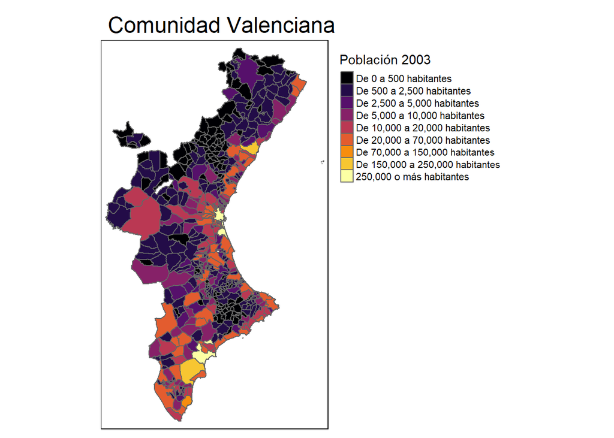

```
## Some legend labels were too wide. These labels have been resized to 0.64. Increase legend.width (argument of tm_layout) to make the legend wider and therefore the labels larger.
```

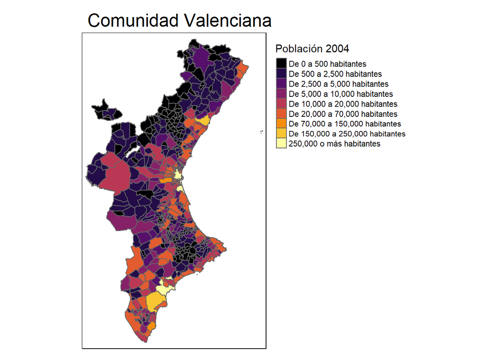

```
## Some legend labels were too wide. These labels have been resized to 0.64. Increase legend.width (argument of tm_layout) to make the legend wider and therefore the labels larger.
```

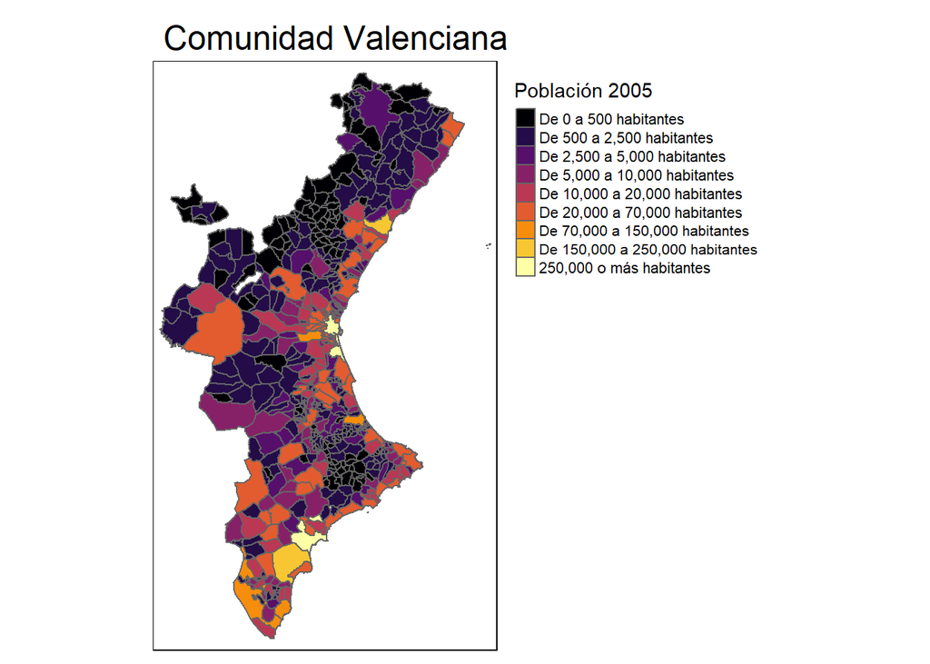

```
## Some legend labels were too wide. These labels have been resized to 0.64. Increase legend.width (argument of tm_layout) to make the legend wider and therefore the labels larger.
```

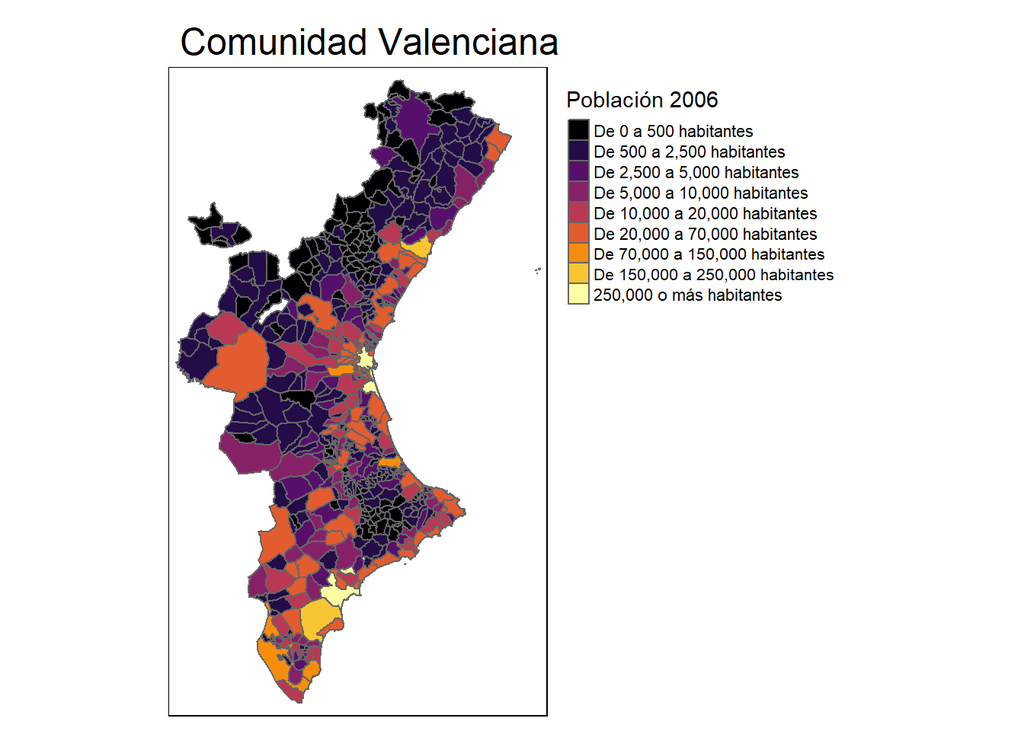

```
## Some legend labels were too wide. These labels have been resized to 0.64. Increase legend.width (argument of tm_layout) to make the legend wider and therefore the labels larger.
```

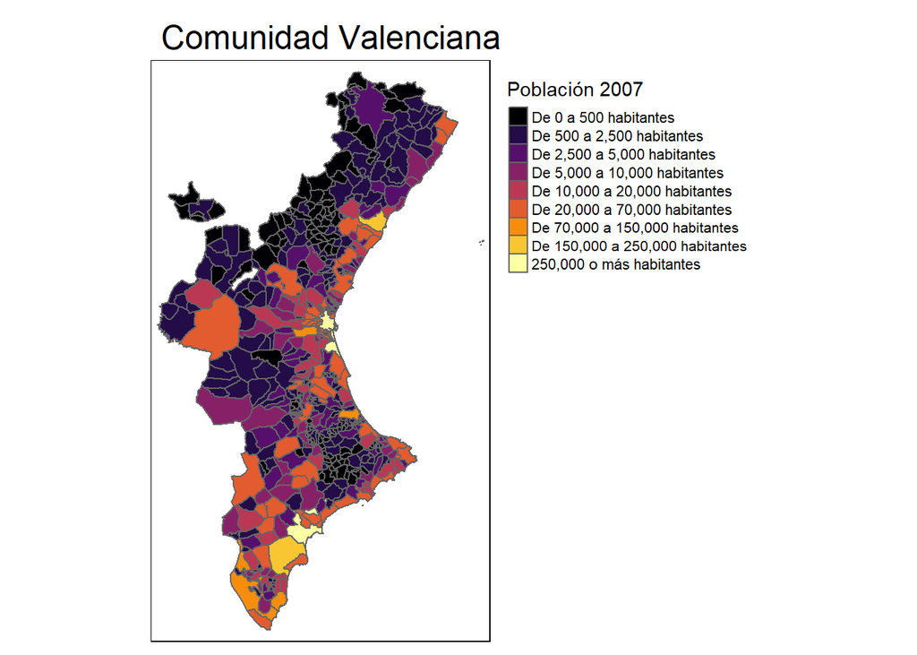

```
## Some legend labels were too wide. These labels have been resized to 0.64. Increase legend.width (argument of tm_layout) to make the legend wider and therefore the labels larger.
```

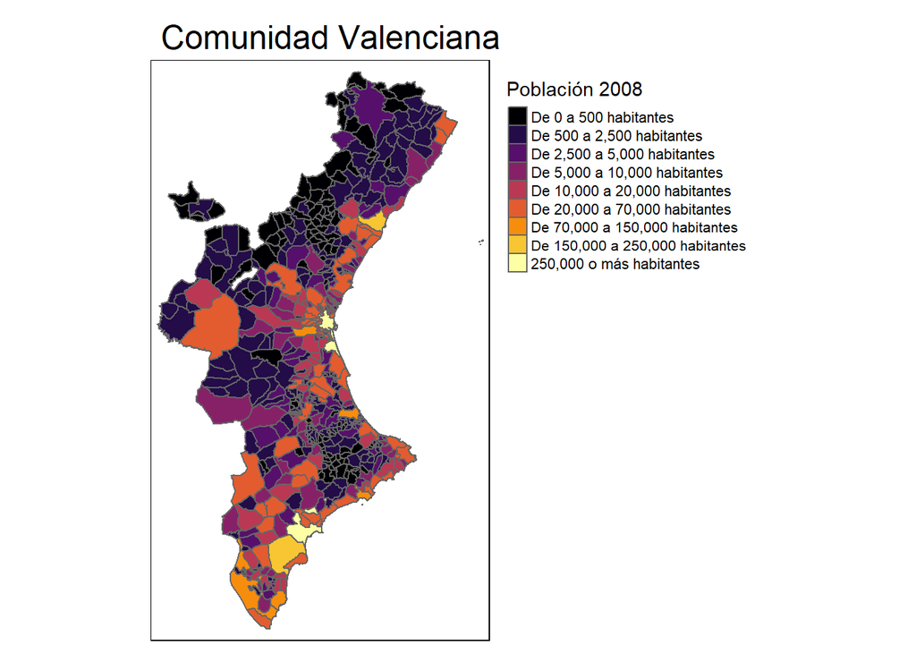

```
## Some legend labels were too wide. These labels have been resized to 0.64. Increase legend.width (argument of tm_layout) to make the legend wider and therefore the labels larger.
```

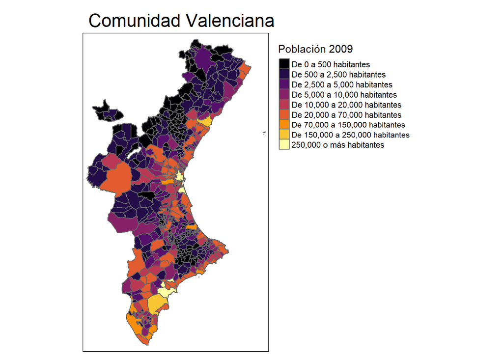

```
## Some legend labels were too wide. These labels have been resized to 0.64. Increase legend.width (argument of tm_layout) to make the legend wider and therefore the labels larger.
```

[9 more figures not shown]

```r
for (j in paste(seq(from=1998,to=2018,by=1))) {
map<-tm_shape(ComVal1)+

    tm_fill(paste(j),
            colorNA=NULL,
            style = "fixed",
            palette = colores,
            breaks = breaks ,
            labels = leyend,
            title = paste("Población",(j)))+tm_borders()+
    tm_layout(main.title = paste("Comunidad Valenciana"),
              title.size = 2,
              legend.outside = T,
              legend.outside.position = c("right"))
      print(map)
}
```

# Faceted maps, de esta manera podemos dibujar todos los mapas desde 1998-2018 e ilustrarlos en una sola imagen

```r
tmap_mode("plot")
```

```
## tmap mode set to plotting
```

```r
tm_shape(ComVal2)+tm_fill(col="population",style = "fixed",palette = colores,breaks=breaks,labels=leyend,title =                     paste("Población"))+
              tm_layout(main.title = paste("Comunidad Valenciana"),
              title.size = 2,
              legend.outside = T,
              legend.outside.position = c("right")) + tm_borders() +
              tm_facets(by= "year",ncol = 3, nrow = 7,free.coords = FALSE)
```

```
## Some legend labels were too wide. These labels have been resized to 0.64. Increase legend.width (argument of tm_layout) to make the legend wider and therefore the labels larger.
```

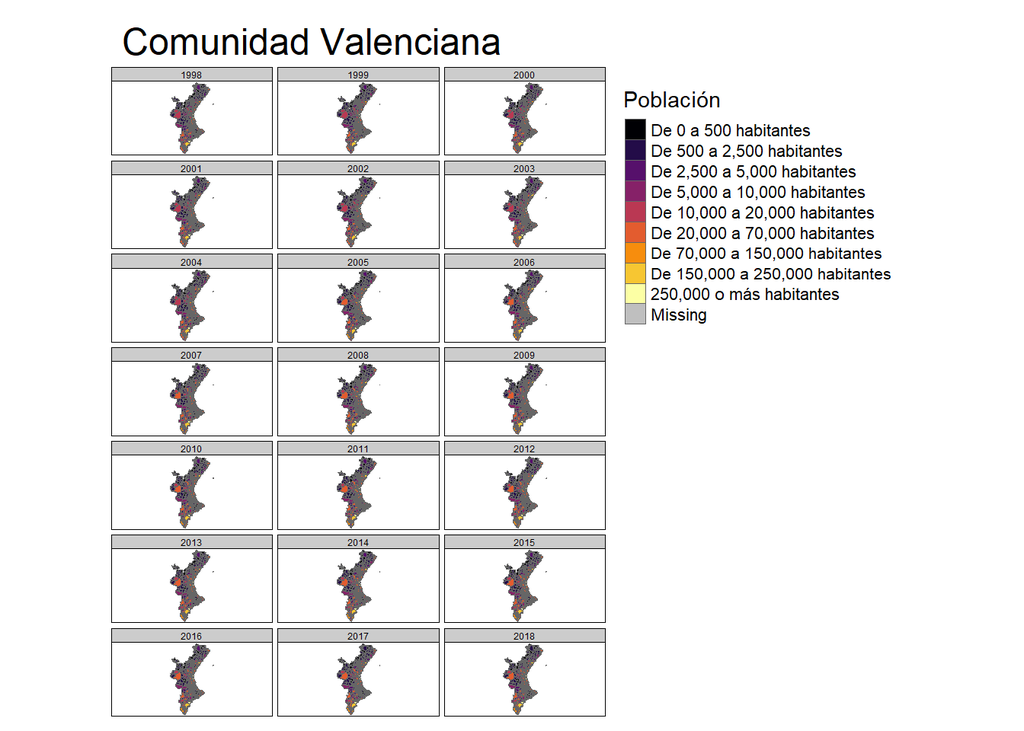

# Animación del mapa

Según el capítulo 8 del libro Geocomputation with R, Making Maps in R haremos un gif de nuestro mapa para los años 1998-2018, y con ello apreciar la evolución de la población mejor Para crear el gif es necesaria la aplicación -> ImageMagick, para integrarlo con RStudio, hemos usado estas instrucciones:

```r
# library(installr)
# devtools::install_github('talgalili/installr')
# install.ImageMagick()
#library(ImageMagick)
```

```r
leg=1998:2018
tmap_mode("plot")
```

```
## tmap mode set to plotting
```

```r
mapvlc<-tm_shape(ComVal2)+tm_fill(col="population",style = "fixed",palette = colores,breaks=breaks,labels=leyend,title =                     paste("Población",paste(leg)))+
              tm_layout(main.title = paste("Comunidad Valenciana"),
              title.size = 2,
              legend.outside = T,
              legend.outside.position = c("right")) + tm_borders() +
              tm_facets(along = "year",free.coords = FALSE)

tmap_animation(mapvlc, filename = "mapvlc.gif", delay = 55)
```

```
## Animation saved to C:\Users\russo\Documents\Master\VAD R y Python\Visualizacion espacial\TareaMapsRusso\mapvlc.gif
```

```r
#gif en carpeta
```